# Melbourne data

Oskar Wiśniewski

2024-10-17

## Wstęp

Celem tego projektu jest analiza danych dotyczących rynku nieruchomości w Melbourne oraz identyfikacja kluczowych czynników wpływających na ceny mieszkań. Na podstawie dostępnych danych przeprowadzę eksplorację wraz z wizualizacją zależności, a następnie zbuduje model predykcyjny wykorzystując do tego algorytm XGBoost.

```r
basic_packages <- c("tidyverse", "tidymodels", "ggthemes", "vip",
                    "dlookr", "gtExtras","scales", "doParallel")

invisible(sapply(basic_packages, library, character.only = TRUE))
```

```r
data <- read_csv("/Users/oskareczqu/Downloads/Melbourne_housing_data.csv", show_col_types = FALSE)
glimpse(data)
```

```
## Rows: 13,580
## Columns: 21
## $ Suburb        <chr> "Abbotsford", "Abbotsford", "Abbotsford", "Abbotsford", …
## $ Address       <chr> "85 Turner St", "25 Bloomburg St", "5 Charles St", "40 F…
## $ Rooms         <dbl> 2, 2, 3, 3, 4, 2, 3, 2, 1, 2, 2, 3, 2, 2, 1, 2, 3, 3, 3,…
## $ Type          <chr> "h", "h", "h", "h", "h", "h", "h", "h", "u", "h", "u", "…
## $ Price         <dbl> 1480000, 1035000, 1465000, 850000, 1600000, 941000, 1876…
## $ Method        <chr> "S", "S", "SP", "PI", "VB", "S", "S", "S", "S", "S", "VB…
## $ SellerG       <chr> "Biggin", "Biggin", "Biggin", "Biggin", "Nelson", "Jelli…
## $ Date          <chr> "3/12/2016", "4/02/2016", "4/03/2017", "4/03/2017", "4/0…
## $ Distance      <dbl> 2.5, 2.5, 2.5, 2.5, 2.5, 2.5, 2.5, 2.5, 2.5, 2.5, 2.5, 2…
## $ Postcode      <dbl> 3067, 3067, 3067, 3067, 3067, 3067, 3067, 3067, 3067, 30…
## $ Bedroom2      <dbl> 2, 2, 3, 3, 3, 2, 4, 2, 1, 3, 2, 3, 2, 2, 1, 2, 3, 2, 3,…
## $ Bathroom      <dbl> 1, 1, 2, 2, 1, 1, 2, 1, 1, 1, 2, 2, 2, 1, 1, 1, 2, 1, 1,…
## $ Car           <dbl> 1, 0, 0, 1, 2, 0, 0, 2, 1, 2, 1, 2, 1, 1, 1, 2, 1, 1, 0,…
## $ Landsize      <dbl> 202, 156, 134, 94, 120, 181, 245, 256, 0, 220, 0, 214, 0…
## $ BuildingArea  <dbl> NA, 79, 150, NA, 142, NA, 210, 107, NA, 75, NA, 190, 94,…
## $ YearBuilt     <dbl> NA, 1900, 1900, NA, 2014, NA, 1910, 1890, NA, 1900, NA, …
## $ CouncilArea   <chr> "Yarra", "Yarra", "Yarra", "Yarra", "Yarra", "Yarra", "Y…
## $ Lattitude     <dbl> -37.7996, -37.8079, -37.8093, -37.7969, -37.8072, -37.80…
## $ Longtitude    <dbl> 144.9984, 144.9934, 144.9944, 144.9969, 144.9941, 144.99…
## $ Regionname    <chr> "Northern Metropolitan", "Northern Metropolitan", "North…
## $ Propertycount <dbl> 4019, 4019, 4019, 4019, 4019, 4019, 4019, 4019, 4019, 40…
```

W tym kroku importujemy dane z pliku CSV i przeglądamy strukturę zbioru, aby upewnić się, że dane zostały poprawnie załadowane.

```r
data <- data %>%
  mutate(Date = dmy(Date)) %>%
  mutate(across(is.character, factor))
```

Tutaj konwertuję predytkor Date z formatu tekstowego na typ daty. Prócz tego zamieniam wszystkie kolumny, które są typu tekstowego na zmienne kategoryczne, co jest bardziej optymalne przy analizie i modelowaniu danych.

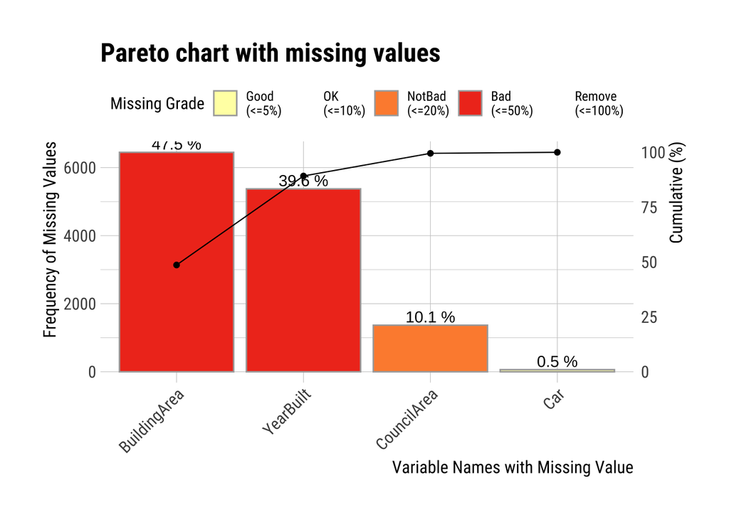

```r
data %>%
  plot_na_pareto(only_na = TRUE)
```

Do modelowania nie bedę brać pod uwagę BuildingArea i YearBuilt, z uwagi na zbyt duże braki w danych, jednak nie usuwam rekordów z wartościami brakującymi w tych zmiennych, aby eksploracyjną analizę danych można było przeprowadzić na reprezentatywnymzbiorze danych

## Eksploracyjna analiza danych

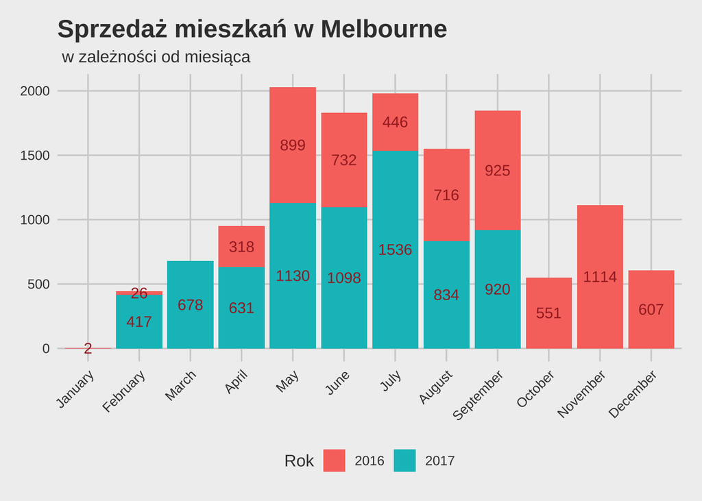

```r
data %>%
  mutate(year = factor(year(Date)), month = month(Date, label = TRUE, abbr = FALSE)) %>%
  group_by(month, year) %>%
  summarise(total_sales = n(), .groups = 'drop') %>%
  ggplot(aes(x = month, y = total_sales, fill = year)) +
  geom_col(position = "stack") +
  geom_text(aes(y = total_sales, label = total_sales),
            position = position_stack(vjust = 0.5), color = "brown") +
  scale_fill_discrete(name = "Rok") +
  theme_fivethirtyeight() +
  theme(axis.text.x = element_text(angle = 45, hjust = 1)) +
  labs(title = "Sprzedaż mieszkań w Melbourne", subtitle = " w zależności od miesiąca",
       x = "Miesiąc", y = "Liczba sprzedaży")
```

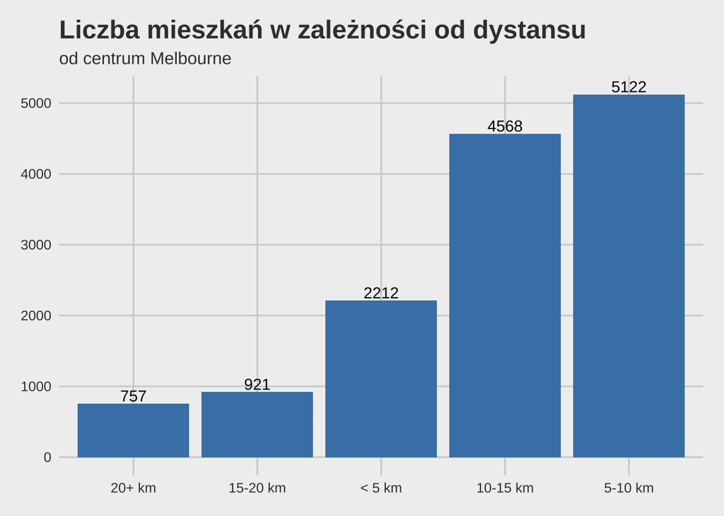

```r
data %>%
  mutate(DistanceGroup = case_when(
    Distance < 5 ~ "< 5 km",
    Distance < 10 ~ "5-10 km",
    Distance < 15 ~ "10-15 km",
    Distance < 20 ~ "15-20 km",
    TRUE ~ "20+ km")) %>%
  group_by(DistanceGroup) %>%
  summarise(Count = n()) %>%
ggplot(aes(x = fct_reorder(DistanceGroup, Count), y = Count)) +
  geom_bar(stat = "identity", fill = "steelblue") +
  geom_text(aes(label = Count), vjust = -0.2) +
  labs(title = "Liczba mieszkań w zależności od dystansu ",
       subtitle = "od centrum Melbourne") +
  theme_fivethirtyeight()
```

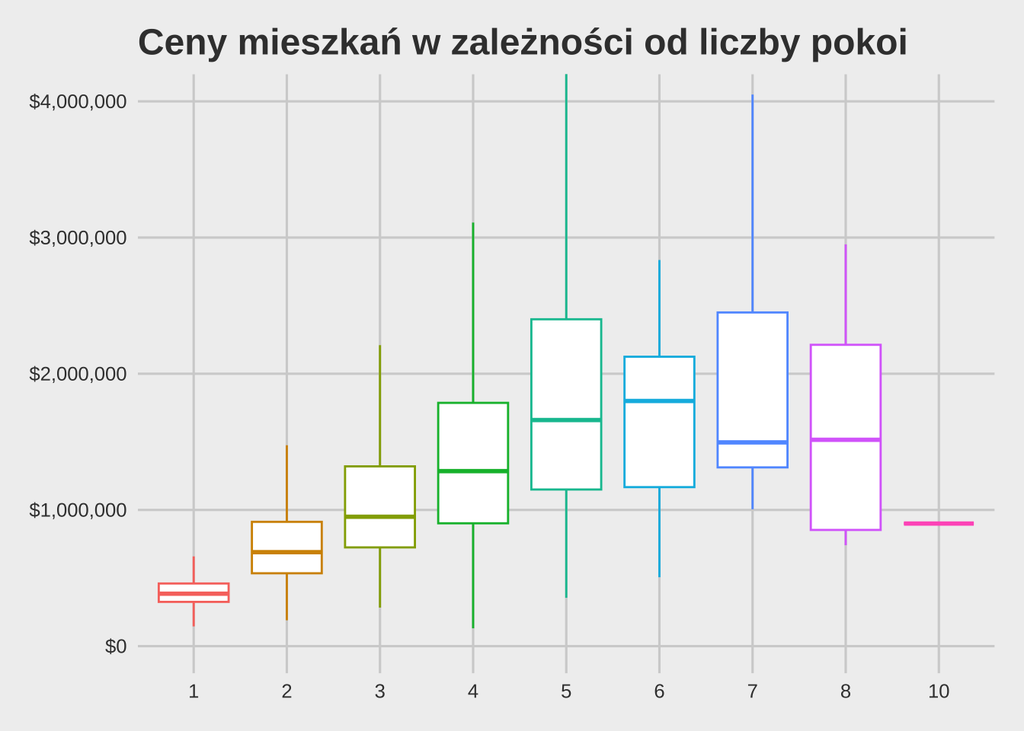

```r
data %>%
  ggplot(aes(x = factor(Rooms), y = Price, color = factor(Rooms))) +
  geom_boxplot(outlier.colour = NA) +
  labs(title = "Ceny mieszkań w zależności od liczby pokoi") +
 theme_fivethirtyeight() +
  scale_y_continuous(labels = label_currency(prefix = "$")) +
  coord_cartesian(ylim = c(0, 4000000)) +
  theme(legend.position = "none")
```

Tutaj widać wykres pudełkowy, który pokazuje zależność między liczbą pokoi a ceną nieruchomości. Widać, że ceny rosną wraz z liczbą pokoi, jednak nie jest to zależność liniowa - przy 7 pokojach lub więcej cena jest średnio coraz niższa. Poza tym istnieje duża zmienność wśród domów z większą liczbą pokoi.

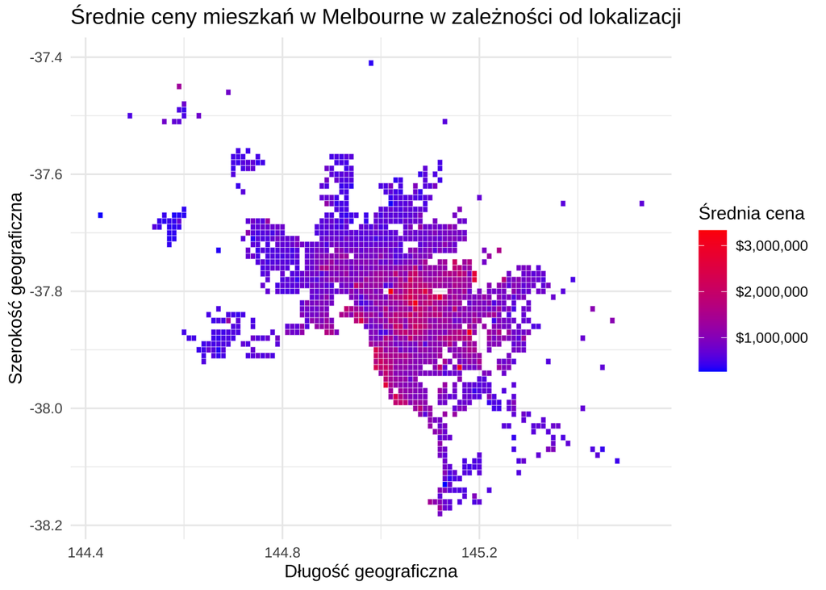

```r
data %>%
  mutate(Longtitude = round(Longtitude, 2),
         Lattitude = round(Lattitude, 2)) %>%
  group_by(Longtitude, Lattitude) %>%
  summarise(AveragePrice = mean(Price), .groups = 'drop') %>%
  ggplot(aes(x = Longtitude, y = Lattitude)) +
  geom_tile(aes(fill = AveragePrice), color = "white") +
  scale_fill_gradient(low = "blue", high = "red",
                      labels = label_currency(prefix = "$")) +
  labs(title = "Średnie ceny mieszkań w Melbourne w zależności od lokalizacji",
       x = "Długość geograficzna",
       y = "Szerokość geograficzna",
       fill = "Średnia cena") +
  theme_minimal()
```

Widać, że najdroższe nieruchomości znajdują się w centrum stolicy Australii, jak i przy samym wybrzeżu.

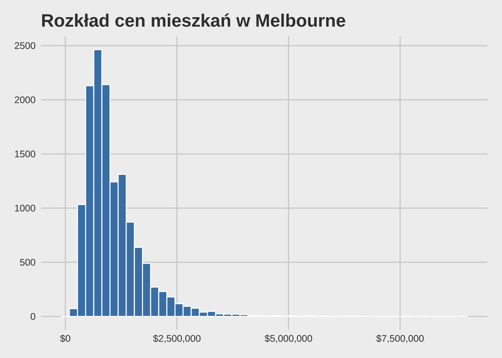

```r
data %>%
  ggplot(aes(x = Price)) +
  geom_histogram(bins = 50, fill = "steelblue", color = "white") +
  labs(title = "Rozkład cen mieszkań w Melbourne") +
  theme_fivethirtyeight() +
  scale_x_continuous(labels = label_currency(prefix = "$"))
```

Histogram pokazuje duże zagęszczenie cen mieszkań w okolicach 1 miliona dolarów, przy silnie prawoskośnym rozkładzie cen, gdzie większość obserwacji skupia się wokół niższych wartości, z kilkoma wyjątkowo drogimi nieruchomościami (outlierami).

```r
data %>%
  filter(Price > 7000000) %>%
  select(Price, Suburb, Rooms, Distance, Bedroom2, Bathroom,
         YearBuilt, BuildingArea, Landsize) %>%
  arrange(-Price)
```

```
## # A tibble: 3 × 9
##    Price Suburb Rooms Distance Bedroom2 Bathroom YearBuilt BuildingArea Landsize
##    <dbl> <fct>  <dbl>    <dbl>    <dbl>    <dbl>     <dbl>        <dbl>    <dbl>
## 1 9   e6 Mulgr…     3     18.8        3        1      1960         117       744
## 2 8   e6 Cante…     5      9          5        5      1880         464.     2079
## 3 7.65e6 Hawth…     4      5.3        4        2      1863         284      1690
```

```r
data_filter <- data %>%
  select(Suburb, Rooms:SellerG, Distance, Bedroom2:Landsize)
```

## Budowa modelu

```r
set.seed(123)
split <- initial_split(data_filter, strata = Price, prop = 0.8)
train <- training(split)
test <- testing(split)
```

Dzielmy nasze dane na zbiór treningowy i testowy.

```r
set.seed(123)
house_folds <- vfold_cv(train, strata = Price)

house_folds
```

```
## #  10-fold cross-validation using stratification
## # A tibble: 10 × 2
##    splits              id
##    <list>              <chr>
##  1 <split [9774/1089]> Fold01
##  2 <split [9774/1089]> Fold02
##  3 <split [9776/1087]> Fold03
##  4 <split [9776/1087]> Fold04
##  5 <split [9777/1086]> Fold05
##  6 <split [9778/1085]> Fold06
##  7 <split [9778/1085]> Fold07
##  8 <split [9778/1085]> Fold08
##  9 <split [9778/1085]> Fold09
## 10 <split [9778/1085]> Fold10
```

Tutaj tworzę obiekt walidacji krzyżowej dla danych treningowych, dzieląc je na 10 “foldów” . Każdy z tych foldów będzie używany do trenowania i walidacji modelu.

```r
xgb_spec <- boost_tree(
  trees = 1000,
  tree_depth = tune(), min_n = tune(),
  loss_reduction = tune(),
  sample_size = tune(), mtry = tune(),
  learn_rate = tune()
) %>%
  set_engine("xgboost") %>%
  set_mode("regression")

xgb_spec
```

```
## Boosted Tree Model Specification (regression)
##
## Main Arguments:
##   mtry = tune()
##   trees = 1000
##   min_n = tune()
##   tree_depth = tune()
##   learn_rate = tune()
##   loss_reduction = tune()
##   sample_size = tune()
##
## Computational engine: xgboost
```

Model XGBoost opiera się na drzewach decyzyjnych, więc nie musimy wykonywać wielu czynności wstępnego przetwarzania naszych danych. Z drugiej strony należy dostroić wiele hiperparametrów modelu.

```r
xgb_grid <- grid_latin_hypercube(
  tree_depth(),
  min_n(),
  loss_reduction(),
  sample_size = sample_prop(),
  finalize(mtry(), train),
  learn_rate(),
  size = 30
)

xgb_grid
```

```
## # A tibble: 30 × 6
##    tree_depth min_n loss_reduction sample_size  mtry    learn_rate
##         <int> <int>          <dbl>       <dbl> <int>         <dbl>
##  1         14    31       2.17e-10       0.526     7 0.00643
##  2          6    28       8.63e-10       0.871    10 0.0655
##  3          9    33       1.18e- 7       0.999     3 0.00000000116
##  4          5    22       2.52e- 4       0.139     9 0.0000302
##  5          1    29       5.62e- 7       0.767     7 0.000440
##  6          5    26       2.24e- 2       0.954     3 0.0000000322
##  7          4    20       3.24e- 2       0.918     5 0.00000000323
##  8          3    17       1.18e- 4       0.198     6 0.00000642
##  9         12    37       4.38e- 5       0.887     7 0.000000179
## 10         14    39       8.20e- 4       0.299     4 0.0267
## # ℹ 20 more rows
```

Skonfigurujmy możliwe wartości tych hiperparametrów do wypróbowania. Użyję do tego projektu wypełniającego przestrzeń, abyśmy mogli jak najlepiej pokryć przestrzeń hiperparametrów.

```r
xgb_wf <- workflow() %>%
  add_formula(Price ~ .) %>%
  add_model(xgb_spec)

xgb_wf
```

```
## ══ Workflow ════════════════════════════════════════════════════════════════════
## Preprocessor: Formula
## Model: boost_tree()
##
## ── Preprocessor ────────────────────────────────────────────────────────────────
## Price ~ .
##
## ── Model ───────────────────────────────────────────────────────────────────────
## Boosted Tree Model Specification (regression)
##
## Main Arguments:
##   mtry = tune()
##   trees = 1000
##   min_n = tune()
##   tree_depth = tune()
##   learn_rate = tune()
##   loss_reduction = tune()
##   sample_size = tune()
##
## Computational engine: xgboost
```

Dla wygody umieśćmy specyfikację modelu w obiekcie typu workflow.

```r
registerDoParallel()

set.seed(123)
xgb_res <- tune_grid(
  xgb_wf,
  resamples = house_folds,
  grid = xgb_grid,
  control = control_grid(save_pred = TRUE)
)

xgb_res
```

```
## # Tuning results
## # 10-fold cross-validation using stratification
## # A tibble: 10 × 5
##    splits              id     .metrics           .notes           .predictions
##    <list>              <chr>  <list>             <list>           <list>
##  1 <split [9774/1089]> Fold01 <tibble [60 × 10]> <tibble [0 × 3]> <tibble>
##  2 <split [9774/1089]> Fold02 <tibble [60 × 10]> <tibble [0 × 3]> <tibble>
##  3 <split [9776/1087]> Fold03 <tibble [60 × 10]> <tibble [0 × 3]> <tibble>
##  4 <split [9776/1087]> Fold04 <tibble [60 × 10]> <tibble [0 × 3]> <tibble>
##  5 <split [9777/1086]> Fold05 <tibble [60 × 10]> <tibble [0 × 3]> <tibble>
##  6 <split [9778/1085]> Fold06 <tibble [60 × 10]> <tibble [0 × 3]> <tibble>
##  7 <split [9778/1085]> Fold07 <tibble [60 × 10]> <tibble [0 × 3]> <tibble>
##  8 <split [9778/1085]> Fold08 <tibble [60 × 10]> <tibble [0 × 3]> <tibble>
##  9 <split [9778/1085]> Fold09 <tibble [60 × 10]> <tibble [0 × 3]> <tibble>
## 10 <split [9778/1085]> Fold10 <tibble [60 × 10]> <tibble [0 × 3]> <tibble>
```

tutaj rejestruję przetwarzanie równoległe z pakietu [doParallel] dla efektywniejszego strojenia hiperparametrów. Ustawiamy seed dla powtarzalności, a tune_grid() wykonuje strojenie siatki dla modelu XGBoost z użyciem walidacji krzyżowej. Wynik zawiera metryki i szczegóły modelu.

```r
show_best(xgb_res, metric = "rmse")
```

```
## # A tibble: 5 × 12
##    mtry min_n tree_depth learn_rate loss_reduction sample_size .metric
##   <int> <int>      <int>      <dbl>          <dbl>       <dbl> <chr>
## 1     8     4         11    0.0175        1.24e- 6       0.811 rmse
## 2    10    28          6    0.0655        8.63e-10       0.871 rmse
## 3     7    31         14    0.00643       2.17e-10       0.526 rmse
## 4     4    39         14    0.0267        8.20e- 4       0.299 rmse
## 5     5    36          3    0.00552       5.14e- 6       0.751 rmse
## # ℹ 5 more variables: .estimator <chr>, mean <dbl>, n <int>, std_err <dbl>,
## #   .config <chr>
```

```r
best_rmse <- select_best(xgb_res, metric = "rmse")
best_rmse
```

```
## # A tibble: 1 × 7
##    mtry min_n tree_depth learn_rate loss_reduction sample_size .config
##   <int> <int>      <int>      <dbl>          <dbl>       <dbl> <chr>
## 1     8     4         11     0.0175     0.00000124       0.811 Preprocessor1_Mo…
```

Wyświetlamy najlepszy wynik modelu dla miary RMSE i wybieramy najlepsze hiperparametry na tej podstawie.

```r
final_xgb <- finalize_workflow(
  xgb_wf,
  best_rmse)

final_xgb
```

```
## ══ Workflow ════════════════════════════════════════════════════════════════════
## Preprocessor: Formula
## Model: boost_tree()
##
## ── Preprocessor ────────────────────────────────────────────────────────────────
## Price ~ .
##
## ── Model ───────────────────────────────────────────────────────────────────────
## Boosted Tree Model Specification (regression)
##
## Main Arguments:
##   mtry = 8
##   trees = 1000
##   min_n = 4
##   tree_depth = 11
##   learn_rate = 0.0174991708818699
##   loss_reduction = 1.24470978060806e-06
##   sample_size = 0.811158082021866
##
## Computational engine: xgboost
```

Finalizujemy workflow dla modelu XGBoost, wykorzystując najlepsze hiperparametry wybrane wcześniej.

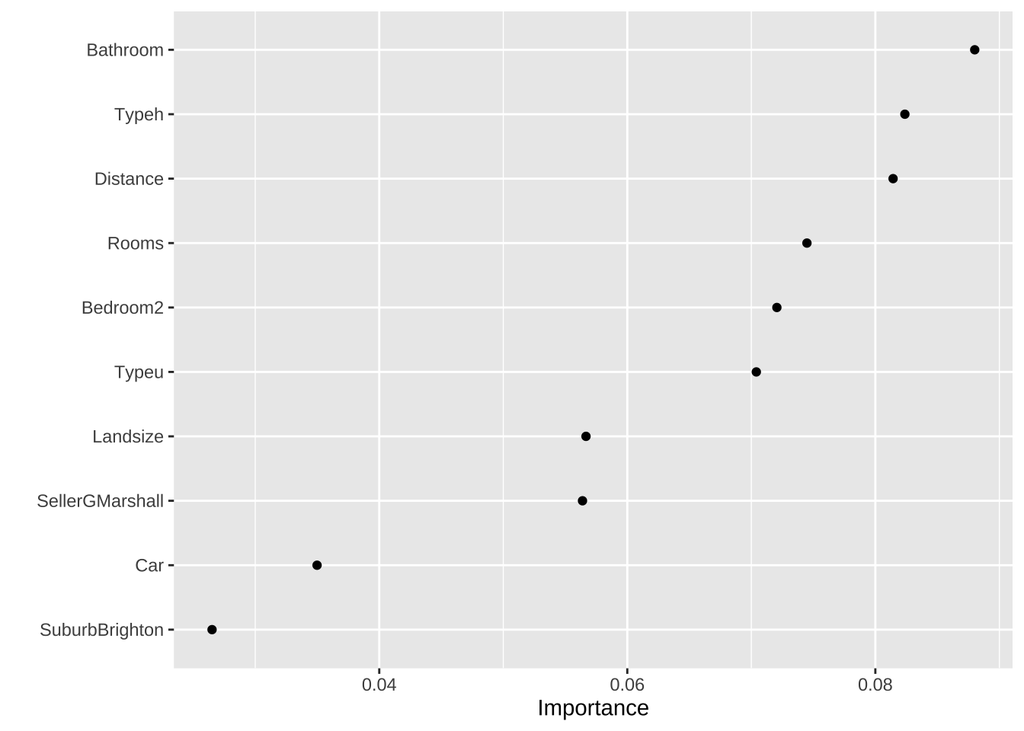

```r
final_xgb %>%
  fit(data = train) %>%
  extract_fit_parsnip() %>%
  vip(geom = "point")
```

```r
final_res <- last_fit(final_xgb, split)
collect_predictions(final_res) %>% metrics(truth = Price, estimate = .pred)
```

```
## # A tibble: 3 × 3
##   .metric .estimator  .estimate
##   <chr>   <chr>           <dbl>
## 1 rmse    standard   343369.
## 2 rsq     standard        0.736
## 3 mae     standard   217419.
```

# Wnioski

W ramach tego projektu przeanalizowano dane dotyczące rynku nieruchomości w Melbourne oraz zbudowano model predykcyjny cen nieruchomości przy użyciu algorytmu XGBoost. Kluczowe wnioski są następujące:

## Problemy z danymi

Zmienna BuildingArea oraz YearBuilt nie zostały uwzględnione w modelu z powodu dużej ilości brakujących wartości. Mimo to dane były wystarczająco reprezentatywne do zbudowania wiarygodnego modelu predykcyjnego.

## Rekomendacje: Wyniki projektu sugerują, że w dalszych analizach warto rozważyć:

- Zgromadzenie bardziej szczegółowych danych dotyczących powierzchni budynków oraz roku budowy, co mogłoby poprawić dokładność modelu.
- Rozważenie bardziej zaawansowanych metod imputacji brakujących danych, aby móc włączyć większą liczbę zmiennych do modelu.

Ogólnie projekt dostarczył wartościowych wglądów w mechanizmy rządzące rynkiem nieruchomości w Melbourne i pozwolił na skuteczne modelowanie cen nieruchomości.